# Exercise A4

## Statistical Analysis of Big Data

Amanda Magzal 207608647

### (a) FP-growth Algorithm

Consider the following transaction data:

| TID | Items |
| --- | --- |
| 1 | {b, a} |
| 2 | {b, c, d} |
| 3 | {a, c, d, e} |
| 4 | {a, d, e} |
| 5 | {b, a, c} |
| 6 | {b, a, c, d} |
| 7 | {a} |
| 8 | {b, a, c} |
| 9 | {b, a, d} |
| 10 | {b, c, e} |

| Item | Support Count |
| --- | --- |
| {a} | 8 |
| {b} | 7 |
| {c} | 6 |
| {d} | 5 |
| {e} | 3 |

The frequent items are sorted in decreasing support counts inside every transaction of the data set.

| TID | Items |
| --- | --- |
| 1 | {a, b} |
| 2 | {b, c, d} |
| 3 | {a, c, d, e} |
| 4 | {a, d, e} |
| 5 | {a, b, c} |
| 6 | {a, b, c, d} |
| 7 | {a} |
| 8 | {a, b, c} |
| 9 | {a, b, d} |
| 10 | {b, c, e} |

Next, the algorithm scans the data set one more time to build the FP-tree.

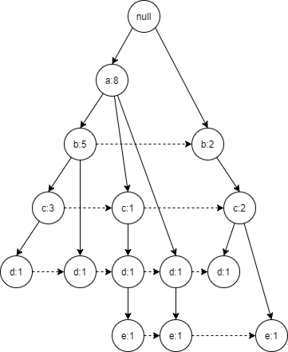

After the tree is ready, the algorithm explores the tree in a bottom-up fashion. It looks for frequent itemsets ending in $e$ first, followed by $d, c, b$ and finally, $a$.

I will show the step-by-step process of finding frequent itemsets ending with $e$. The same process is then applied on $d, c, b$ and $a$.

(1) Gather all prefix paths - paths containing the node $e$.

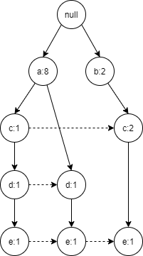

(2) Calculate the support count for $e$ from the prefix paths. The required minimum support is 2, and {$e$} has support count 3. Thus, it is a frequent itemset.

(3) Convert the prefix paths into a conditional FP-tree using the following steps:

```
 - Update the support counts to include only the transactions that contain the item $e$.
 - Remove the nodes for $e$.
 - Eliminate items that have become infrequent.
```

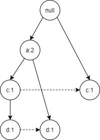

(4) Use the conditional FP-tree for $e$ to solve the subproblems of finding frequent itemsets ending in $de, ce$ and $ae$.

- Gather the prefix paths for $d$, and calculate the support count for {$d, e$}. Since it is equal to 2, {$d, e$} is a frequent itemset.

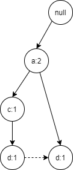

- Construct the conditional FP-tree for $de$ (using step 3). The tree contains only one item ($a$) which is frequent. Thus, {$a, d, e$} is a frequent itemset.
- Gather the prefix paths for $c$, and calculate the support count for {$c, e$}. Since it is equal to 2, {$c, e$} is a frequent itemset.

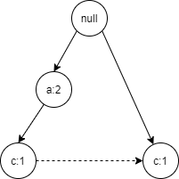

- Construct the conditional FP-tree for $ce$ (using step 3). The tree contains only one item ($a$) which is infrequent. Thus, {$a, c, e$} is not a frequent itemset.
- Gather the prefix paths for $a$, and calculate the support count for {$a, e$}. Since it is equal to 2, {$a, e$} is a frequent itemset.

The algorithm proceeds with the same devide-and-conquer approach to find all frequent itemsets ending with $d, c, b$ and $a$.

The final result is shown in the following table:

[output not shown]

### (b) Apriori Algorithm

Consider the following transaction data:

```python
import pandas as pd
import time
from mlxtend.frequent_patterns import apriori
from mlxtend.frequent_patterns import association_rules

df = pd.read_excel('Online Retail.xlsx')
df.head()
```

|  | InvoiceNo | StockCode | Description | Quantity | InvoiceDate | UnitPrice | CustomerID | Country |
| --- | --- | --- | --- | --- | --- | --- | --- | --- |
| 0 | 536365 | 85123A | WHITE HANGING HEART T-LIGHT HOLDER | 6 | 2010-12-01 08:26:00 | 2.55 | 17850.0 | United Kingdom |
| 1 | 536365 | 71053 | WHITE METAL LANTERN | 6 | 2010-12-01 08:26:00 | 3.39 | 17850.0 | United Kingdom |
| 2 | 536365 | 84406B | CREAM CUPID HEARTS COAT HANGER | 8 | 2010-12-01 08:26:00 | 2.75 | 17850.0 | United Kingdom |
| 3 | 536365 | 84029G | KNITTED UNION FLAG HOT WATER BOTTLE | 6 | 2010-12-01 08:26:00 | 3.39 | 17850.0 | United Kingdom |
| 4 | 536365 | 84029E | RED WOOLLY HOTTIE WHITE HEART. | 6 | 2010-12-01 08:26:00 | 3.39 | 17850.0 | United Kingdom |

#### Cleanup

```python
df.dropna(axis=0, subset=['InvoiceNo'], inplace=True)
df['InvoiceNo'] = df['InvoiceNo'].astype('str')
df = df[~df['InvoiceNo'].str.contains('C')]
```

#### Consolidation and One Hot Encoding

```python
basket = (df[df['Country'] =="France"]
          .groupby(['InvoiceNo', 'Description'])['Quantity']
          .sum().unstack().reset_index().fillna(0)
          .set_index('InvoiceNo'))
```

```python
def encode_units(x):
    if x <= 0:
        return 0
    if x >= 1:
        return 1

basket_sets = basket.applymap(encode_units)
basket_sets.drop('POSTAGE', inplace=True, axis=1)
```

#### Applying the Algorithm

```python
start = time.time()
frequent_itemsets = apriori(basket_sets, min_support=0.07, use_colnames=True)
rules = association_rules(frequent_itemsets, metric="lift", min_threshold=1)
end = time.time()
run_time = end - start
rules.head()
```

|  | antecedents | consequents | antecedent support | consequent support | support | confidence | lift | leverage | conviction |
| --- | --- | --- | --- | --- | --- | --- | --- | --- | --- |
| 0 | (ALARM CLOCK BAKELIKE PINK) | (ALARM CLOCK BAKELIKE GREEN) | 0.102041 | 0.096939 | 0.073980 | 0.725000 | 7.478947 | 0.064088 | 3.283859 |
| 1 | (ALARM CLOCK BAKELIKE GREEN) | (ALARM CLOCK BAKELIKE PINK) | 0.096939 | 0.102041 | 0.073980 | 0.763158 | 7.478947 | 0.064088 | 3.791383 |
| 2 | (ALARM CLOCK BAKELIKE RED ) | (ALARM CLOCK BAKELIKE GREEN) | 0.094388 | 0.096939 | 0.079082 | 0.837838 | 8.642959 | 0.069932 | 5.568878 |
| 3 | (ALARM CLOCK BAKELIKE GREEN) | (ALARM CLOCK BAKELIKE RED ) | 0.096939 | 0.094388 | 0.079082 | 0.815789 | 8.642959 | 0.069932 | 4.916181 |
| 4 | (ALARM CLOCK BAKELIKE PINK) | (ALARM CLOCK BAKELIKE RED ) | 0.102041 | 0.094388 | 0.073980 | 0.725000 | 7.681081 | 0.064348 | 3.293135 |

```python
print('The run time for the Apriori algorithm is ' + str(round(run_time, 4)))
```

```
The run time for the Apriori algorithm is 0.026
```

### (c) Comparing the Algorithms

```python
import pyfpgrowth
from pyspark.mllib.fpm import FPGrowth
from mlxtend.preprocessing import TransactionEncoder


dataset = [['Milk', 'Onion', 'Nutmeg', 'Kidney Beans', 'Eggs', 'Yogurt'],
           ['Dill', 'Onion', 'Nutmeg', 'Kidney Beans', 'Eggs', 'Yogurt'],
           ['Milk', 'Apple', 'Kidney Beans', 'Eggs'],
           ['Milk', 'Unicorn', 'Corn', 'Kidney Beans', 'Yogurt'],
           ['Corn', 'Onion', 'Onion', 'Kidney Beans', 'Ice cream', 'Eggs']]

te = TransactionEncoder()
te_ary = te.fit(dataset).transform(dataset)
df = pd.DataFrame(te_ary, columns=te.columns_)
```

```python
# Apriori
start = time.time()
apriori_res = apriori(df, min_support=0.6, use_colnames=True)
end = time.time()
apriori_time = end - start
apriori_res
```

|  | support | itemsets |
| --- | --- | --- |
| 0 | 0.8 | (Eggs) |
| 1 | 1.0 | (Kidney Beans) |
| 2 | 0.6 | (Milk) |
| 3 | 0.6 | (Onion) |
| 4 | 0.6 | (Yogurt) |
| 5 | 0.8 | (Eggs, Kidney Beans) |
| 6 | 0.6 | (Eggs, Onion) |
| 7 | 0.6 | (Kidney Beans, Milk) |
| 8 | 0.6 | (Kidney Beans, Onion) |
| 9 | 0.6 | (Kidney Beans, Yogurt) |
| 10 | 0.6 | (Eggs, Kidney Beans, Onion) |

```python
# FP-Growth
start = time.time()
fp_res = pyfpgrowth.find_frequent_patterns(dataset, support_threshold=3)
end = time.time()
fp_time = end - start
fp_res
```

```
{('Milk',): 3,
 ('Kidney Beans', 'Milk'): 3,
 ('Yogurt',): 3,
 ('Kidney Beans', 'Yogurt'): 3,
 ('Onion',): 4,
 ('Kidney Beans', 'Onion'): 4,
 ('Eggs', 'Onion'): 4,
 ('Eggs', 'Kidney Beans'): 4,
 ('Eggs', 'Kidney Beans', 'Onion'): 4,
 ('Kidney Beans',): 5}
```

```python
# Parallel FP-Growth
start = time.time()
par_res = FPGrowth.FreqItemset(df, freq=0.6)
end = time.time()
par_time = end - start
par_res
```

```
FreqItemset(items=   Apple   Corn   Dill   Eggs  Ice cream  Kidney Beans   Milk  Nutmeg  Onion  \
0  False  False  False   True      False          True   True    True   True
1  False  False   True   True      False          True  False    True   True
2   True  False  False   True      False          True   True   False  False
3  False   True  False  False      False          True   True   False  False
4  False   True  False   True       True          True  False   False   True

   Unicorn  Yogurt
0    False    True
1    False    True
2    False   False
3     True    True
4    False   False  , freq=0.6)
```

```python
pd.DataFrame([apriori_time, fp_time, par_time], columns=['Time'], index=['Apriori', 'FP-Growth', 'Parallel FP-Growth'])
```

|  | Time |
| --- | --- |
| Apriori | 0.004955 |
| FP-Growth | 0.000997 |
| Parallel FP-Growth | 0.000000 |

### (d) Change the Data Set

```python
new_dataset = [['Milk', 'Onion', 'Nutmeg'],
               ['Dill', 'Yogurt'],
               ['Apple', 'Kidney Beans'],
               ['Unicorn', 'Corn'],
               ['Ice cream', 'Eggs']]

te = TransactionEncoder()
te_ary = te.fit(new_dataset).transform(new_dataset)
df = pd.DataFrame(te_ary, columns=te.columns_)

# Apriori
start = time.time()
apriori(df, min_support=0.2, use_colnames=True)
end = time.time()
apriori_time = end - start

# FP-Growth
start = time.time()
pyfpgrowth.find_frequent_patterns(new_dataset, 2)
end = time.time()
fp_time = end - start

pd.DataFrame([apriori_time, fp_time], columns=['Time'], index=['Apriori', 'FP-Growth'])
```

|  | Time |
| --- | --- |
| Apriori | 0.009003 |
| FP-Growth | 0.001002 |